# research

2024-05-29

# Preambula

Numerous studies has been dedicated to the area of brand-naming. Some of the researches are trying to discover the correlation between brand names likelihood and the sounds they use. Such attempt to map all concepts to specific sounds, is called sound mapping. In the following research:

Trninić, Z. (2023). Creating effective brand names with sound symbolic mappings. Strategic Management-International Journal of Strategic Management and Decision Support Systems in Strategic Management, 28(2).

author has been investigated that different phonemes are associated with different qualities of objects. For example, active articulators such as /p/, /b/, /m/ are uttered more frequently when it comes to large objects. Despite the fact that results of the paper’s investigation indeed justify the hypothesis, the methodology is quit debatable. The most fallible part if presumption is that chosen products i.e. razors and soaps are associated with nothing more but sharpness ans softness. The problem is that razor are actually might be associated with softness, since for some people it is desirable to not get a scratch from using it. The aim of this paper is to conduct similar experiment but with notion that the way people associate products is relative to each respondent. Hence, the design of new experiment is the following: 1. For each respondent we generate 6 unique combinations of words. The very words’ structure is CV-CV-CV, where each CV is from common categories. 2. Then we ask to give an association for chosen word 3. and at last we ask to chose the word again

# Data Description

Main data: user_id - simply an id of respondent firstly_chosen_group - the category of a word that was chosen by a user from the start of survey associations - chosen word’s associations that user came up with image - a descriptive image of chosen word that user came up with is_interested - yes/no answer to the question: would you be interested in a product simply because of the name you chose lastly_chosen_group - the category of a word that was chosen by a user at the end of survey

features data: transformed main data where associations and image column’s values were used to calculate their own phonetic group stats

# libraries

```r
library(dplyr)
```

```r
library(ggplot2)
library(tidyverse)
```

# Uploading data

## main data

```r
data <- read.csv(file="https://raw.githubusercontent.com/XvKuoMing/PhonoSymbolism/main/responses.csv",
                 head=TRUE,
                 sep=",",
                 stringsAsFactors = TRUE
                 )
data
```

```
##       user_id     firstly_chosen_group                             associations
## 1   138061640        upper_teeth+front                                  игрушка
## 2   192381075         upper_teeth+back                                  Испания
## 3   358763582         soft_palate+back                      С чем то китайскими
## 4   362747599         upper_teeth+back     Что-то иностранное, новое, необычное
## 5   374853018 active_articulator+front                                   машины
## 6   404814319  active_articulator+back                                   Африка
## 7   437812839         soft_palate+back                        корм для животных
## 8   463001428        upper_teeth+front революционный товар первой необходимости
## 9   490107634         upper_teeth+back                                    света
## 10  493831663         upper_teeth+back                   Музыкальный инструмент
## 11  683395329         upper_teeth+back                                 качество
## 12  724081281        upper_teeth+front                                     зубы
## 13  732874568         soft_palate+back                             с спортпитом
## 14  741441151         upper_teeth+back                                   тойота
```

[output cut: 93 more lines]

## support data

```r
features <- read.csv("https://raw.githubusercontent.com/XvKuoMing/PhonoSymbolism/main/responses_with_features.csv",
                     head=TRUE,
                     sep=',',
                     stringsAsFactors = TRUE)
features$lastly_chosen_group <- as.integer(features$lastly_chosen_group)
features$firstly_chosen_group <- as.integer(features$firstly_chosen_group)
features$is_interested <- as.integer(features$is_interested)
features
```

```
##     X    user_id firstly_chosen_group is_interested lastly_chosen_group
## 1   0  138061640                    5             2                   6
## 2   1  192381075                    4             2                   1
## 3   2  358763582                    3             1                   3
## 4   3  362747599                    4             1                   5
## 5   4  374853018                    2             1                   6
## 6   5  404814319                    1             1                   3
## 7   6  437812839                    3             1                   5
## 8   7  463001428                    5             1                   3
## 9   8  490107634                    4             1                   3
## 10  9  493831663                    4             2                   6
## 11 10  683395329                    4             1                   5
## 12 11  724081281                    5             1                   6
## 13 12  732874568                    3             1                   4
## 14 13  741441151                    4             1                   2
```

[output cut: 57 more lines]

# Basic stats

## main data stats

```r
# create long pivot format
order_group_data <-
data %>%
  select(firstly_chosen_group, lastly_chosen_group) %>%
  pivot_longer(
    cols=c("firstly_chosen_group", "lastly_chosen_group"),
    names_to="order",
    values_to="group"
  )
order_group_data
```

```
## # A tibble: 70 × 2
##    order                group
##    <chr>                <fct>
##  1 firstly_chosen_group upper_teeth+front
##  2 lastly_chosen_group  upper_teeth+front
##  3 firstly_chosen_group upper_teeth+back
##  4 lastly_chosen_group  active_articulator+back
##  5 firstly_chosen_group soft_palate+back
##  6 lastly_chosen_group  soft_palate+back
##  7 firstly_chosen_group upper_teeth+back
##  8 lastly_chosen_group  upper_teeth+back
##  9 firstly_chosen_group active_articulator+front
## 10 lastly_chosen_group  upper_teeth+front
## # ℹ 60 more rows
```

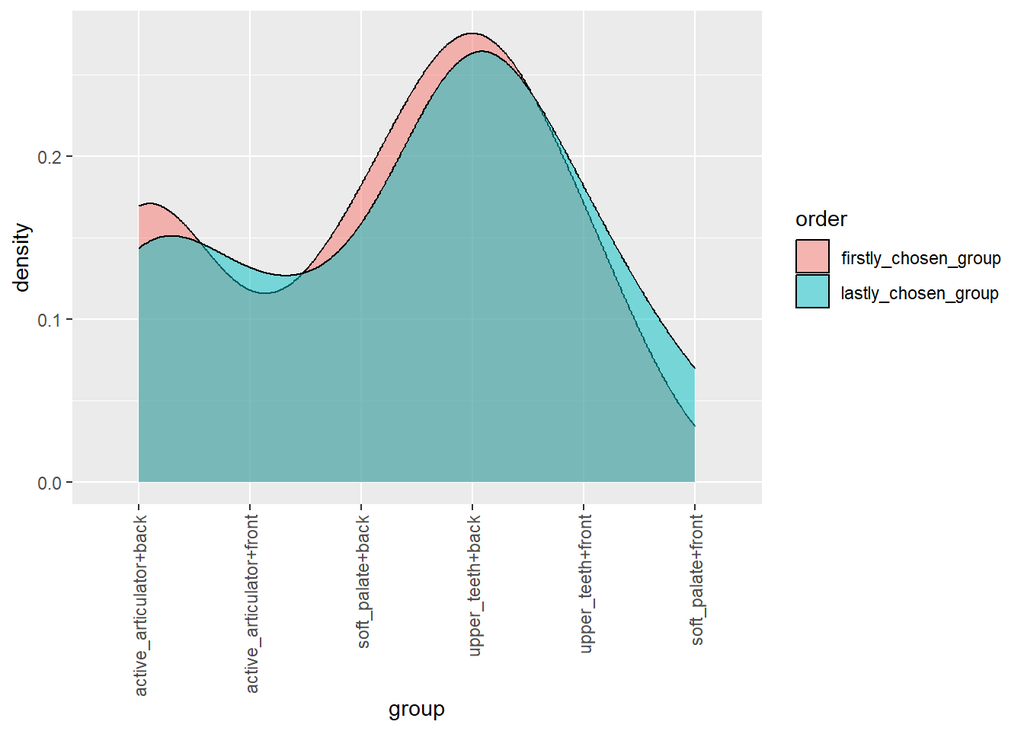

```r
# group distribution for each order
ggplot(data=order_group_data,
       aes(x=group, group=order, fill=order)) +
  geom_density(alpha = 0.5) +
  scale_x_discrete(guide = guide_axis(angle = 90))
```

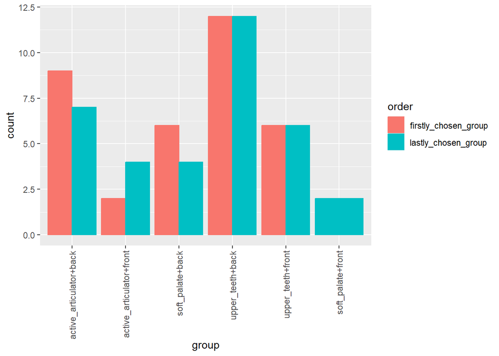

```
It seems that first and last groups are distributed equally. However, we need to check their contingency
```

```r
# other way to print distribution
ggplot(data=order_group_data,
       aes(x=group,
           color=order,
           fill=order
           )
       ) +
  geom_bar(position="dodge") +
  scale_x_discrete(guide = guide_axis(angle = 90))
```

```r
# contingency table
data.tabs <-
data %>%
  select(firstly_chosen_group, lastly_chosen_group) %>%
  table()
data.tabs
```

```
##                           lastly_chosen_group
## firstly_chosen_group       active_articulator+back active_articulator+front
##   active_articulator+back                        5                        1
##   active_articulator+front                       0                        1
##   soft_palate+back                               0                        0
##   upper_teeth+back                               2                        2
##   upper_teeth+front                              0                        0
##                           lastly_chosen_group
## firstly_chosen_group       soft_palate+back soft_palate+front upper_teeth+back
##   active_articulator+back                 1                 0                2
##   active_articulator+front                0                 0                0
##   soft_palate+back                        1                 1                4
##   upper_teeth+back                        1                 1                4
##   upper_teeth+front                       1                 0                2
##                           lastly_chosen_group
## firstly_chosen_group       upper_teeth+front
##   active_articulator+back                  0
##   active_articulator+front                 1
##   soft_palate+back                         0
##   upper_teeth+back                         2
##   upper_teeth+front                        3
```

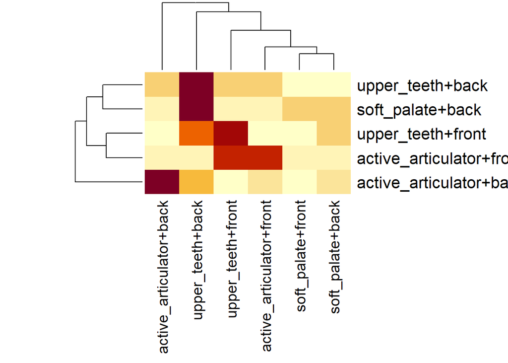

```
active_artucalor+back & upper_teeth:back not only very popular choices, but also repetitive
```

```r
# heatmap visualization
prop.table(data.tabs) %>%
  heatmap(margins=c(14, 7))
```

```r
# let's calculate the accuracy
equal_responses <- sum(as.character(data$firstly_chosen_group) == as.character(data$lastly_chosen_group))
accuracy <- equal_responses / nrow(data)

cat(accuracy * 100, "%")
```

```
## 40 %
```

```r
# before now we calculated the whole phonetically combination. However, vowels and consonants individually might have influence on choices
data.separated <-
data %>%
  select(user_id, is_interested, firstly_chosen_group, lastly_chosen_group) %>%
  separate(firstly_chosen_group, c("firstly_con", "firstly_vow"), sep='\\+') %>%
  separate(lastly_chosen_group, c("lastly_con", "lastly_vow"), sep='\\+')

equal_responses_con <- sum(as.character(data.separated$firstly_con) == as.character(data.separated$lastly_con))
accuracy_con <- equal_responses_con / nrow(data.separated)
equal_responses_vow <- sum(as.character(data.separated$firstly_vow) == as.character(data.separated$lastly_vow))
accuracy_vow <- equal_responses_vow / nrow(data.separated)

cat("Accuracy of consonants repetition", accuracy_con, "\n")
```

```
## Accuracy of consonants repetition 0.5714286
```

```r
cat("Accuracy of vowels repetition", accuracy_vow, "\n")
```

```
## Accuracy of vowels repetition 0.7142857
```

```r
cat("Mean accuracy", (accuracy_con + accuracy_vow) / 2, "\n")
```

```
## Mean accuracy 0.6428571
```

```r
# let's see the most popular consonants
data.separated.cons_tab <-
data.separated %>%
  select(firstly_con, lastly_con) %>%
  table()
data.separated.cons_tab
```

```
##                     lastly_con
## firstly_con          active_articulator soft_palate upper_teeth
##   active_articulator                  7           1           3
##   soft_palate                         0           2           4
##   upper_teeth                         4           3          11
```

```r
# do the same for vowels
data.separated.vow_tab <-
data.separated %>%
  select(firstly_vow, lastly_vow) %>%
  table()
data.separated.vow_tab
```

```
##            lastly_vow
## firstly_vow back front
##       back    20     7
##       front    3     5
```

## support data stats

```r
# beside our phonetics group there might be some influence from other variables, such as interest.
# For example, user may chose a phonetic group that he himself is not interested to. It would break the main idea of experiment i.e. repetition on group choices indicates the preferability of group as commercial product. Hence, we need to check data for such cases
data.interest <-
  data %>%
  select(firstly_chosen_group, is_interested) %>%
  table()
data.interest
```

```
##                           is_interested
## firstly_chosen_group       да нет
##   active_articulator+back   6   3
##   active_articulator+front  2   0
##   soft_palate+back          6   0
##   upper_teeth+back          8   4
##   upper_teeth+front         5   1
```

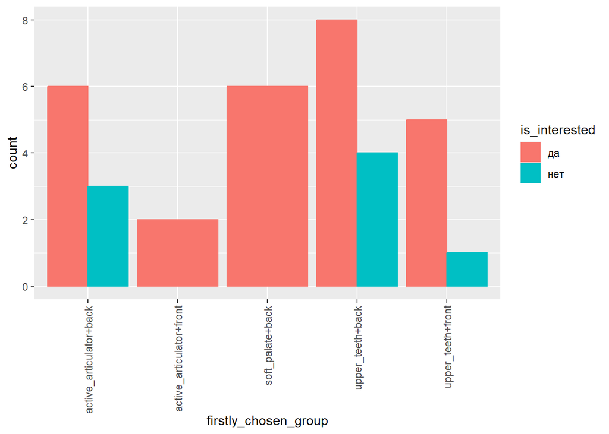

```r
ggplot(data=data,
       aes(x=firstly_chosen_group,
           color=is_interested,
           fill=is_interested
           )
       ) +
  geom_bar(position="dodge") +
  scale_x_discrete(guide = guide_axis(angle = 90))
```

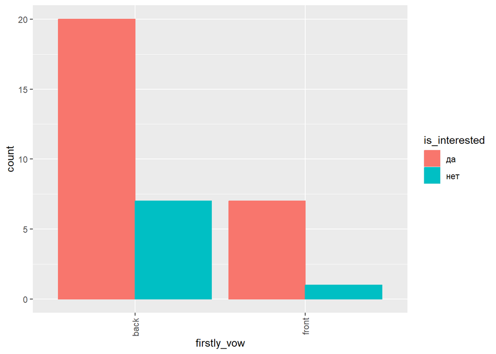

```r
# do the same for vowels and consonants, starting with vowels
data.separated %>%
  select(firstly_vow, is_interested) %>%
  ggplot(aes(x=firstly_vow,
             color=is_interested,
             fill=is_interested
           )
         ) +
  geom_bar(position="dodge") +
  scale_x_discrete(guide = guide_axis(angle = 90))
```

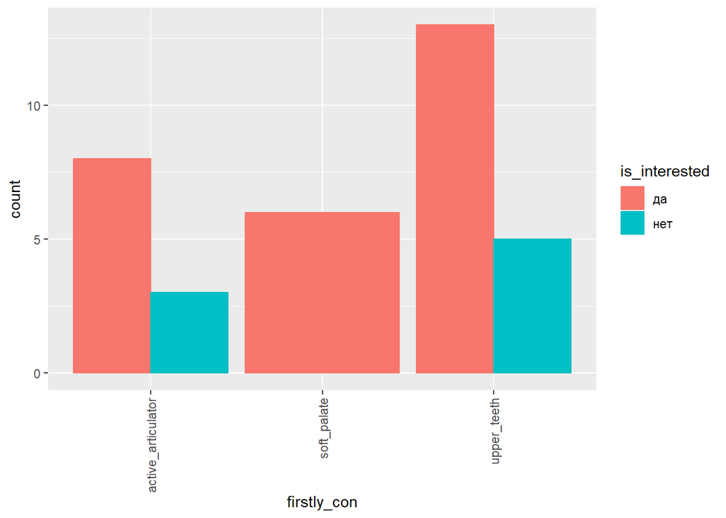

```r
data.separated %>%
  select(firstly_con, is_interested) %>%
  ggplot(aes(x=firstly_con,
             color=is_interested,
             fill=is_interested
           )
         ) +
  geom_bar(position="dodge") +
  scale_x_discrete(guide = guide_axis(angle = 90)) # we can see that positive answer is dominant
```

```r
# Now, let's see if there is any influence of chosen word to association
# firstly, print summary stats for count of each phonetic group in association+image
features %>%
  select(soft_palate, back, front, active_articulator, upper_teeth) %>%
  summary()
```

```
##   soft_palate       back            front        active_articulator
##  Min.   :0.0   Min.   : 1.000   Min.   : 1.000   Min.   :0.0
##  1st Qu.:1.0   1st Qu.: 4.500   1st Qu.: 3.000   1st Qu.:1.0
##  Median :2.0   Median : 7.000   Median : 5.000   Median :2.0
##  Mean   :2.4   Mean   : 7.314   Mean   : 5.629   Mean   :2.4
##  3rd Qu.:3.0   3rd Qu.:10.000   3rd Qu.: 7.000   3rd Qu.:3.0
##  Max.   :7.0   Max.   :16.000   Max.   :16.000   Max.   :7.0
##   upper_teeth
##  Min.   : 1.000
##  1st Qu.: 3.000
##  Median : 5.000
##  Mean   : 5.686
##  3rd Qu.: 8.000
##  Max.   :13.000
```

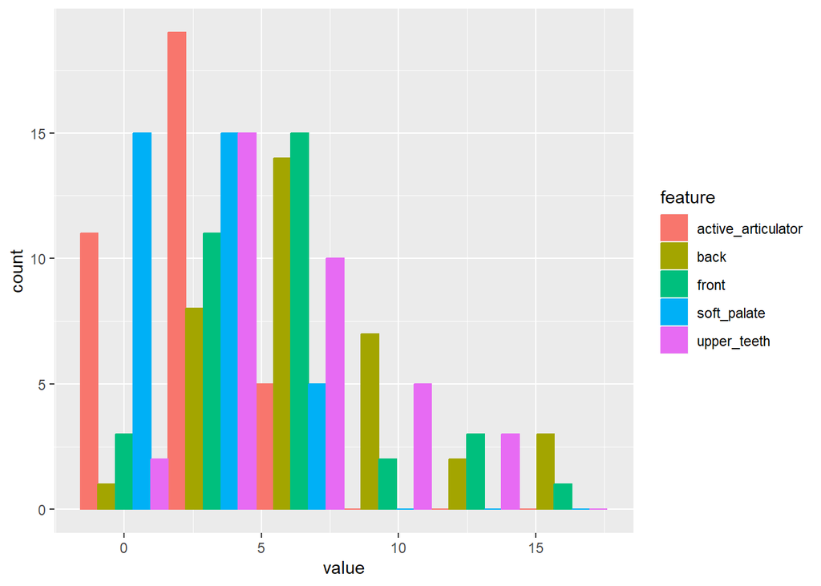

```r
# phonetic group distribution in association+image
features %>%
  pivot_longer(c("back", "active_articulator", "upper_teeth", "front", "soft_palate"),
               names_to = "feature",
               values_to = "value") %>%
  select(feature, value) %>%
  ggplot(
    aes(x=value,
        fill=feature,
        color=feature)
  ) +
  geom_histogram(position="dodge", bins=6)
```

```r
# check normality distribution using shapiro test
features %>%
  select(firstly_chosen_group, back, upper_teeth, active_articulator, front, soft_palate) %>%
  group_by(firstly_chosen_group) %>%
  apply(2, shapiro.test) # for majority of variables p-value < 0.05, ==> there are not normally distributed
```

```
## $firstly_chosen_group
##
##  Shapiro-Wilk normality test
##
## data:  newX[, i]
## W = 0.84443, p-value = 0.0001728
##
##
## $back
##
##  Shapiro-Wilk normality test
##
## data:  newX[, i]
## W = 0.94864, p-value = 0.1029
##
##
## $upper_teeth
##
##  Shapiro-Wilk normality test
##
## data:  newX[, i]
## W = 0.91389, p-value = 0.009542
##
##
## $active_articulator
##
##  Shapiro-Wilk normality test
##
## data:  newX[, i]
## W = 0.92338, p-value = 0.01786
##
##
## $front
##
##  Shapiro-Wilk normality test
##
## data:  newX[, i]
## W = 0.90738, p-value = 0.006282
##
##
## $soft_palate
##
##  Shapiro-Wilk normality test
##
## data:  newX[, i]
## W = 0.89402, p-value = 0.002741
```

# Tests

## main test

```
Since we are dealing with categorical variables and the size of samples is relativelty small, then it is a good idea to use Fisher Test:
H0: the last choice of word group is NOT influenced by choice of first word group
H1: the last choice of word group is influenced by choice of first word group
```

```r
fisher.test(data.tabs)
```

```
##
##  Fisher's Exact Test for Count Data
##
## data:  data.tabs
## p-value = 0.1299
## alternative hypothesis: two.sided
```

```
The p-value is > 0.05, which gives us a reason to accept h0. However, we should also check consonants and vowels independently
```

```r
# vowels
data.separated.vow_tab %>%
  fisher.test()
```

```
##
##  Fisher's Exact Test for Count Data
##
## data:  .
## p-value = 0.09116
## alternative hypothesis: true odds ratio is not equal to 1
## 95 percent confidence interval:
##   0.678275 37.232819
## sample estimates:
## odds ratio
##   4.521953
```

```r
# consonants
data.separated.cons_tab %>%
  fisher.test()
```

```
##
##  Fisher's Exact Test for Count Data
##
## data:  .
## p-value = 0.05415
## alternative hypothesis: two.sided
```

```
Vowels and consonants independently still have p-value > 0.0.5, which means that there are no statistically meaningfull reason to reject h0.
```

## support tests

```
Let's test support data
```

### Interest independence

```
H0: There is not relation between interest and word's category choices
H1: There is a relation between interest and word's category choices
```

```r
data %>%
  select(is_interested, firstly_chosen_group) %>%
  table() %>%
  fisher.test()
```

```
##
##  Fisher's Exact Test for Count Data
##
## data:  .
## p-value = 0.5389
## alternative hypothesis: two.sided
```

```r
data %>%
  select(is_interested, lastly_chosen_group) %>%
  table() %>%
  fisher.test()
```

```
##
##  Fisher's Exact Test for Count Data
##
## data:  .
## p-value = 0.1033
## alternative hypothesis: two.sided
```

```r
data.separated %>%
  select(is_interested, firstly_vow) %>%
  table() %>%
  fisher.test()
```

```
##
##  Fisher's Exact Test for Count Data
##
## data:  .
## p-value = 0.6478
## alternative hypothesis: true odds ratio is not equal to 1
## 95 percent confidence interval:
##  0.007944023 4.343897562
## sample estimates:
## odds ratio
##  0.4172543
```

```r
data.separated %>%
  select(is_interested, lastly_vow) %>%
  table() %>%
  fisher.test()
```

```
##
##  Fisher's Exact Test for Count Data
##
## data:  .
## p-value = 0.4024
## alternative hypothesis: true odds ratio is not equal to 1
## 95 percent confidence interval:
##   0.3402123 16.0226126
## sample estimates:
## odds ratio
##   2.312389
```

```r
data.separated %>%
  select(is_interested, firstly_con) %>%
  table() %>%
  fisher.test()
```

```
##
##  Fisher's Exact Test for Count Data
##
## data:  .
## p-value = 0.4894
## alternative hypothesis: two.sided
```

```r
data.separated %>%
  select(is_interested, lastly_con) %>%
  table() %>%
  fisher.test()
```

```
##
##  Fisher's Exact Test for Count Data
##
## data:  .
## p-value = 1
## alternative hypothesis: two.sided
```

```
For each test their p-value > 0.05, which means that there is not dependency between interest and phonetical combination
```

## association independence

```
Since more than a half of our phonetic groups are not normally distributed. Let's try to test their influency using generalised linear regression with Poisson ditribution
```

```r
glm_first_group <-
  glm(firstly_chosen_group ~ active_articulator + upper_teeth + back + front + soft_palate,
      data=features,
      family = poisson())
summary(glm_first_group)
```

```
##
## Call:
## glm(formula = firstly_chosen_group ~ active_articulator + upper_teeth +
##     back + front + soft_palate, family = poisson(), data = features)
##
## Coefficients:
##                    Estimate Std. Error z value Pr(>|z|)
## (Intercept)         1.04851    0.21098   4.970  6.7e-07 ***
## active_articulator  0.02037    0.07233   0.282   0.7782
## upper_teeth         0.08155    0.04755   1.715   0.0864 .
## back               -0.06863    0.05908  -1.162   0.2454
## front              -0.03398    0.04262  -0.797   0.4253
## soft_palate         0.10254    0.08005   1.281   0.2002
## ---
## Signif. codes:  0 '***' 0.001 '**' 0.01 '*' 0.05 '.' 0.1 ' ' 1
##
## (Dispersion parameter for poisson family taken to be 1)
##
##     Null deviance: 27.098  on 34  degrees of freedom
## Residual deviance: 21.984  on 29  degrees of freedom
## AIC: 135.24
##
## Number of Fisher Scoring iterations: 4
```

```
It seems that intercept does all the work, which means that our phonems have no influenct on association and image.
```

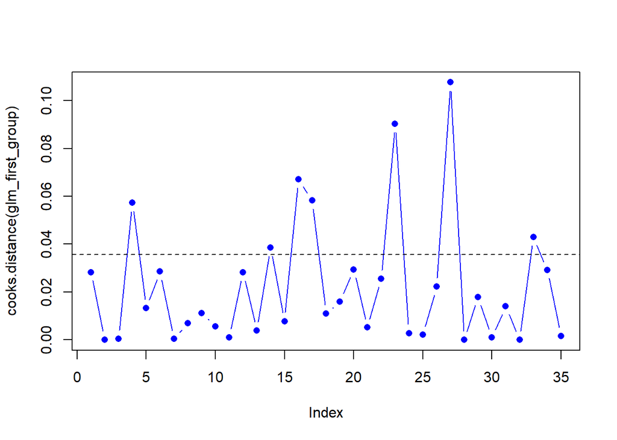

```r
plot(cooks.distance(glm_first_group), type='b', pch = 16, col = "blue")
N <- nrow(features)
k <- 6
cutoff <- 1 / (N - k - 1)
abline(h=cutoff,lty=2)
```

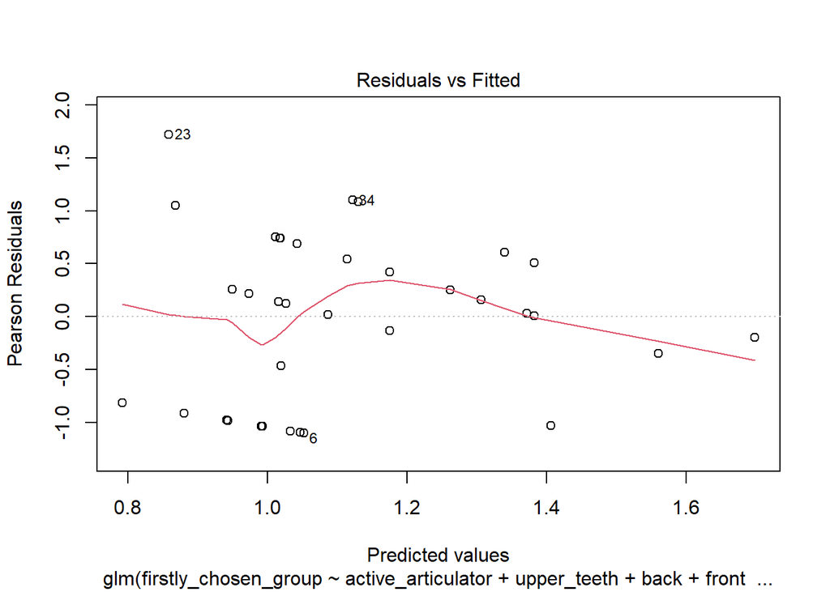

```r
plot(glm_first_group, which=1)
```

# Conclusion

```
It seems that all connections between choices in our sample is a coincidance or there is not enough data to check statistically meaningfull connections between phonetical groups and commercial names
```